Some random notebook to test your ability to use markdowns!  
Michał Łaźniewki

[click me to find out more about markdowns](https://jupyter-notebook.readthedocs.io/en/stable/examples/Notebook/Working%20With%20Markdown%20Cells.html)

[figure not shown]

Powered by Python3

This is some random text here because there is nothing to write about. What do you write about when someone forces you to write about stuff? You have to make up stuff and I am not very good at this. I think this will do.

## 1.1 Intro

Hopefully this section has more interesting stuff. Not really. You are mistaken. This section is even more boring than the previous section. But in this section, we are going to have some python chunks. Some of which you will put in a final report to gloat you know python.

```python
x=list(range(10))
[i for i in x]
```

```
[0, 1, 2, 3, 4, 5, 6, 7, 8, 9]
```

But wait, we shoul always start with:

```python
print('Hello world!')
```

```
Hello world!
```

## 1.2 Plots

Here is a basic plot done with matplotlib. It shows … well nothing specific.  
To visualize a plot with matplotlib in notebook you need to start a chunk of code with “%Matplotlib inline”, just don’t ask me why ! We will cover plots later (much later) … so no just copy-paste this chunk

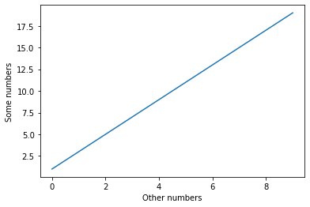

```python
%matplotlib inline
import matplotlib.pyplot as plt

y = list(range(1,20,2))

plt.plot(x,y)
plt.ylabel('Some numbers')
plt.xlabel('Other numbers')
plt.show()
```

## 1.3 Image

So can include a random image here? Of course we can, here is an image:

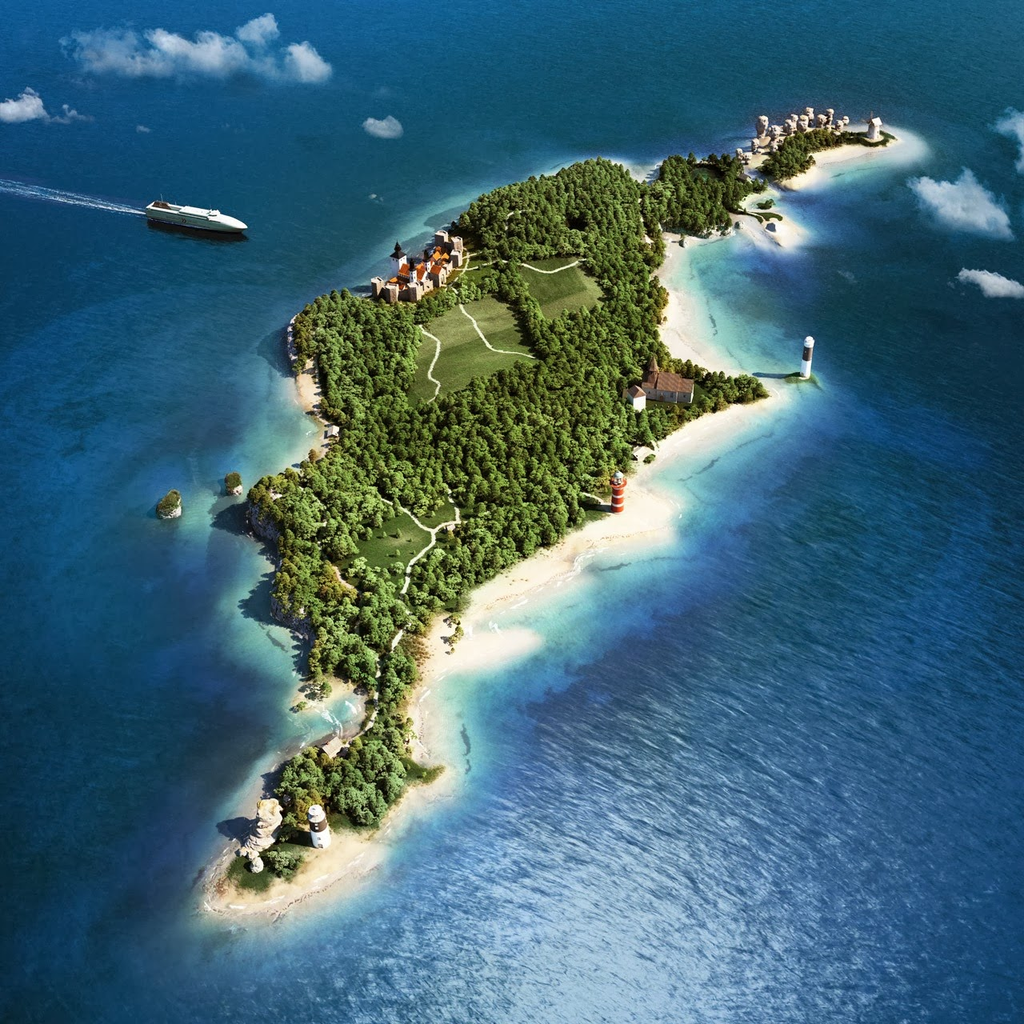

This is an aerial view of Gotland (not a real image). But it’s cute and I went there to learn R… Did you notice the Rauks on the top right? The course I attended was called Rauk**R** … what a twist :)

## 1.4 Tables

This is a simple table, can you write it down yourself ?

| No. | speed | dist |
| --- | --- | --- |
| 1 | 30 | 60 |
| 2 | 12 | 24 |
| 3 | 130 | 1000 |

## 1.5 Equation

Yor final task is to write down pdf for the normal distribution, it usually terrifies my students, but you **are** mathematicians, so it should be a piece of cake. You only need to know how to write a fraction (“\frac”), square root (“\sqrt”)

## 1.6 Lists

So we can also create lists in markdowns. What can we put here…hmm maybe my favourite TV shows:

> - Star Trek:TOS
> - Star Trek TAS
> - Star Trek TNG
> - Star Trek DS9

I guess you can *guess* the rest :)

## 1.7 Markdown and html

If you know html (I don’t but I can use Google…) you can include html chunk directy in the report, they will be included in the knitted version. Take a look here:

> This text was altered by using html directly !

this was achieved by typing:

`<font style="font-family: times, serif; font-size:11pt; font-style:italic; color:red">`  
> This text was altered by using html directly  
`</font>`

That’s all, really !

**End of document**